# Uma Proposta de Workflow Mínimo para Manuseio de Dados em R

## Uma Proposta de *Workflow* Mínimo para Manuseio de Dados em R

## O que veremos

1. Etapas de uma Análise de Dados
2. Uma Proposta de *Workflow*
3. Implementando o *SEU* Projeto

## Etapas de uma Análise de Dados

## Etapas de uma Análise de Dados

1. Coleta de Dados
2. Preparação dos Dados
3. Análise dos Dados
4. Comunicação dos Achados

## Etapas de uma Análise de Dados

### Preparação dos Dados

- Repita quantas vezes precisar:
1. Importação dos Dados
2. Crítica dos Dados
   - Análise Descritiva
   - Visualização dos Dados
3. Se Encontrou Problemas:
   - Verificação dos Dados
     - Listagem de Valores a Verificar
   - Repetir o Ciclo

## Etapas de uma Análise de Dados

### Análise dos Dados

- Repita quantas vezes precisar:
1. Visualização dos Dados
2. Análise Descritiva/Análise Exploratória
3. Análise Inferencial/Modelagem Formal
4. Se o Resultado da Análise for insatisfatório:
   - Transformação dos Dados
   - Repetir o Ciclo

## Etapas de uma Análise de Dados

### Comunicação dos Achados

1. Representação Visual dos Achados
2. Relato Textual e Interpretação dos Achados

## Uma Proposta de *Workflow*

## Uma Proposta de *Workflow*

1. Preparação do ambiente de análise de dados
2. Preparação dos Dados
3. Análise dos Dados + Relatório da Análise

## Uma Proposta de *Workflow*

1. Preparação do ambiente de análise de dados
   1. Crie uma pasta nova para o projeto
      - subpasta para os arquivos de dados originais
   2. Crie um projeto (`.Rproj`) no `R Studio`
      - use o Sistema de Controle de Versão `Git`
2. Preparação dos Dados
3. Análise dos Dados + Relatório da Análise

## Uma Proposta de *Workflow*

1. Preparação do ambiente de análise de dados
2. Preparação dos Dados
   1. Crie um programa `.R` para a Importação
      - Crie um arquivo `.Rdata` com os dados importados
   2. Crie um documento `.Rmd` para a Documentação do Conjunto de Dados
   3. Crie um programa `.R` para a Crítica
3. Análise dos Dados + Relatório da Análise

## Uma Proposta de *Workflow*

1. Preparação do ambiente de análise de dados
2. Preparação dos Dados
3. Análise dos Dados + Relatório da Análise
   1. Crie um documento `.Rmd` para a Análise Descritiva/Exploratória
   2. Crie um documento `.Rmd` para a Análise Inferencial/Modelagem

## Etapas Abordadas neste Curso

1. Preparação do ambiente de análise de dados
   - Estrutura de pastas para o projeto
   - Projeto no `R Studio` com controle de versão
2. Preparação dos Dados
   - Programa para a Importação
   - Documentação do Conjunto de Dados
   - Programa para a Crítica

## Implementando o *SEU* Projeto

## Implementando o *SEU* Projeto

- Projeto no `R Studio`
- Programa de Importação
- Documentação do Conjunto de Dados
- Programa de Crítica

## Projeto no `R Studio`

## Projeto no `R Studio`

Ok, Agora é a hora de *Você* começar a usar o *seu* conjunto de dados.

Vamos começar criando um projeto novo no `R Studio`.

## Projeto no `R Studio`

Abra o `R Studio` e clique no Botão `Project: (None)`.

[figure not shown]

## Projeto no `R Studio`

Clique em `New Project`.

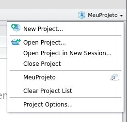

## Projeto no `R Studio`

Clique em `New Directory`.

[figure not shown]

## Projeto no `R Studio`

Clique em `Empty Project`.

[figure not shown]

## Projeto no `R Studio`

1. Digite em `Directory Name` o nome da pasta a ser criada .
2. `Browse...` serve para mudar onde a pasta será criada.
3. **IMPORTANTE**: habilite a opção `Create a git repository`.

[figure not shown]

## Projeto no `R Studio`

Note:

[figure not shown]

## Projeto no `R Studio`

Note:

1. o nome do projeto acima do painel superior direito;
2. o nome da pasta na Aba `Console` no painel inferior esquerdo;
3. o conteúdo da pasta (com um arquivo `.Rproj`) na Aba `Files` no painel inferior direito; e
4. que existe uma Aba `Git` no painel superior direito.

## Projeto no `R Studio`

Clique no Botão `New Folder` dentro da Aba `Files`.

[figure not shown]

## Projeto no `R Studio`

Digite `originais` como nome da nova pasta que você vai criar.

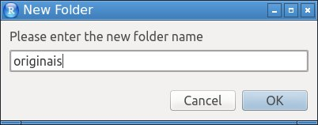

## Projeto no `R Studio`

Copie agora os arquivos de dados originais para dentro da pasta `originais` que você acabou de criar.

Não continue antes de realizar esta etapa!

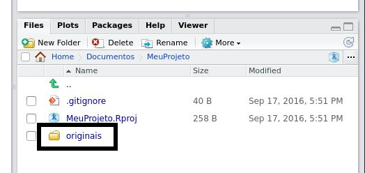

## Projeto no `R Studio`

Clique na Aba `Git` para ver o sistema de controle de versão.

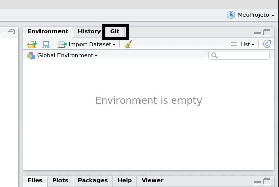

## Projeto no `R Studio`

Clique no Botão `Commit` para abrir a janela do sistema de controle de versão

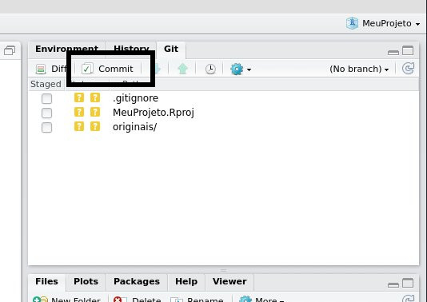

## Sistema de Controle de Versão

Note na janela superior esquerda.

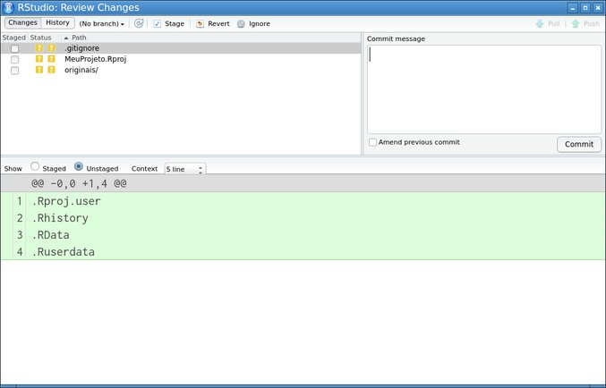

## Sistema de Controle de Versão

Isso significa que o sistema de controle de versão não sabe o que você quer fazer com esses arquivos.

Você pode:

1. monitorar e salvar as mudanças feitas no arquivo com a opção `Stage`;
2. descartar todas as mudanças no arquivo e recuperar a versão anterior com a opção `Revert`; e
3. escolher nunca monitorar as modificações do arquivo com a opção `Ignore`

## Sistema de Controle de Versão

Selecione a caixa na Coluna `Staged` do primeiro item e note que as `?` em amarelo da Coluna `Status` mudaram para um único `A` único em verde.

[figure not shown]

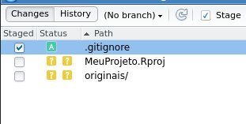

Isso que dizer que o sistema de controle de versão vai incluir esse arquivo na lista de arquivos a serem monitorados.

## Sistema de Controle de Versão

Selecione a caixa na Coluna `Staged` de todos os outros itens e note que as `?` em amarelo da Coluna `Status` mudaram para um único `A` único em verde.

[figure not shown]

[figure not shown]

Isso que dizer que o sistema de controle de versão vai incluir todos esse arquivo na lista de arquivos a serem monitorados.

## Sistema de Controle de Versão

Digite `commit inicial` na caixa de texto na Janela `Commit message` e clique no Botão `Commit` para registrar a primeira versão desses arquivos.

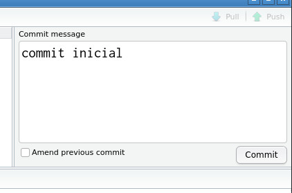

## Sistema de Controle de Versão

Se apareceu uma janela como esta, então tudo correu bem.

Clique no Botão `Close`

[figure not shown]

## Sistema de Controle de Versão

Agora, você deve estar vendo a janela do sistema de controle de versão sem nenhum item na lista da janela superior esquerda.

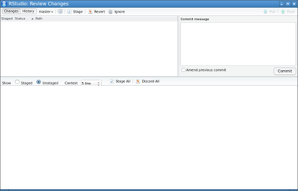

Isso significa que não há alterações a serem nem salvas, nem descartadas e nem revertidas.

## Sistema de Controle de Versão

Na próxima vez que você for registrar as alterações que você fizer, cada arquivo será comparado com a última versão salva e as modificações encontradas em cada arquivo serão armazenadas no repositório que foi criado.

Assim, o seu projeto vai sendo salvo a cada *commit*, de modo que será possível rastrear as modificações feitas ao longo do projeto e até mesmo reverter o projeto para qualquer etapa salva.

Veremos mais sobre isso ao longo do curso.

## Voltando um pouco…

Volte para a apresentação  
Tratamento e Manuseio de Dados com R

## Programa de Importação

## Programa de Importação

## Documentação do Conjunto de Dados

## Documentação do Conjunto de Dados